# Customer Sales Analysis Report

# Introduction

This report analyzes customer sales data to understand purchasing patterns and customer behavior. The analysis focuses on demographic factors, spending patterns, and time-based trends.

## Data Overview

The dataset contains information about 10 customers, including their demographics and purchasing behavior. Let’s start by examining some key statistics here in Table 1.

Table 1

```
  customer_id         age           gender              income
 Min.   : 1.00   Min.   :24.00   Length:10          Min.   : 48000
 1st Qu.: 3.25   1st Qu.:29.75   Class :character   1st Qu.: 67500
 Median : 5.50   Median :37.50   Mode  :character   Median : 81500
 Mean   : 5.50   Mean   :37.30                      Mean   : 79800
 3rd Qu.: 7.75   3rd Qu.:44.00                      3rd Qu.: 91000
 Max.   :10.00   Max.   :52.00                      Max.   :110000
 items_purchased  total_spent         date
 Min.   :2.00    Min.   : 95.3   Min.   :2024-01-15
 1st Qu.:3.25    1st Qu.:181.6   1st Qu.:2024-01-17
 Median :4.50    Median :216.6   Median :2024-01-19
 Mean   :4.70    Mean   :224.7   Mean   :2024-01-19
 3rd Qu.:5.75    3rd Qu.:278.6   3rd Qu.:2024-01-21
 Max.   :8.00    Max.   :356.8   Max.   :2024-01-24
```

## Customer Demographics and Spending

The age distribution of our customers shows an interesting pattern:

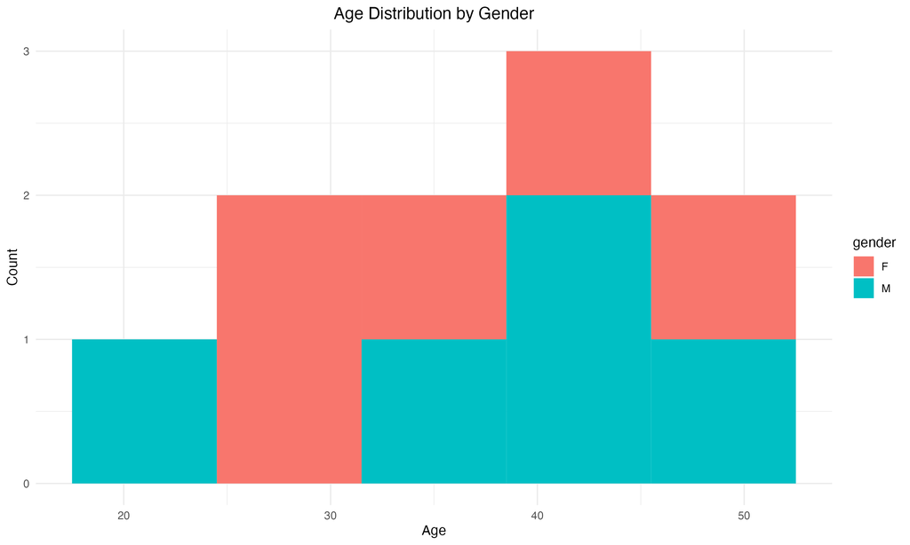

Figure 1: Age Distribution

## Spending Patterns

The relationship between income and total spending reveals some interesting insights:

[figure not shown]

Figure 2: Income vs Total Spent

## Daily Sales Trends

Looking at the daily sales trend:

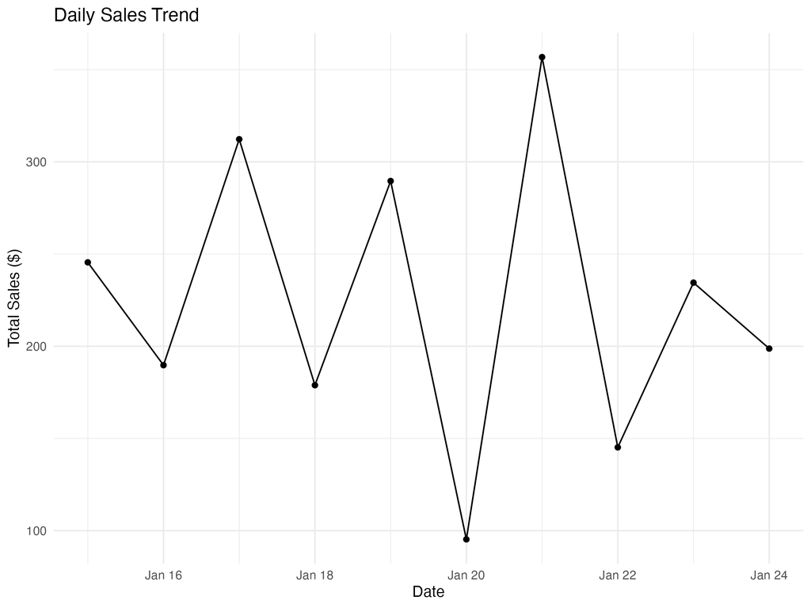

Figure 3: Daily Sales Trend

We can observe some variation in daily sales, with certain days showing higher spending patterns. This could be valuable information for inventory and staffing planning.

## Recommendations

Based on this analysis, we recommend:

1. Further investigation into the factors that influence spending beyond income level
2. Analysis of product categories to understand what drives higher spending
3. Consideration of targeted marketing strategies for different age groups
4. Development of a more sophisticated inventory management system based on daily sales patterns

## Conclusion

This analysis provides valuable insights into customer behavior and spending patterns. The findings can be used to optimize business operations and develop more targeted marketing strategies. Further analysis with a larger dataset would help validate these findings and provide more detailed insights.